# Final Report

## Introduction

Human trafficking remains the fastest-growing crime on the planet, impacting millions of lives worldwide. Due to its underground nature, identifying and combating this crime requires robust and comprehensive intervention methods. The U.S. Department of State’s Trafficking in Persons (TIP) report annually categorizes countries into Tiers based on their government response. However, the criteria for these placements can appear vague and may fail to recognize countries making significant progress despite structural challenges. For example, countries in Southern and Eastern Europe, burdened with historical political instability and economic limitations, face higher rates of human trafficking. Despite their efforts to address the issue, Tier placements may undervalue their progress, especially when compared to wealthier, more stable nations in Northern and Western Europe.

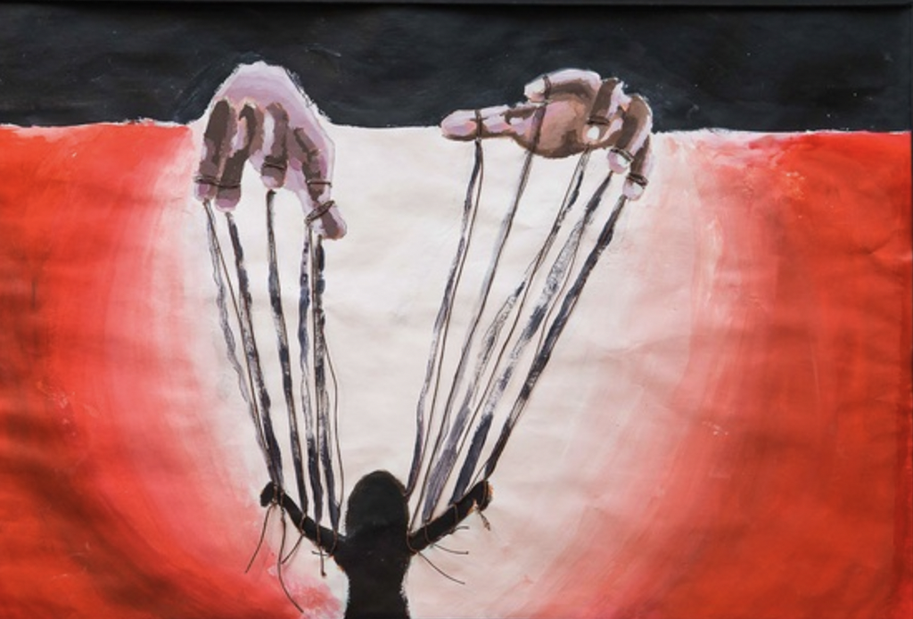

In this project, various indicators collected from independent sources were combined, analyzed, and modeled together with the aim of drawing a better understanding of what variables may explain factors in the problem arena of the world’s fastest growing and most complex underground crime, human trafficking. Particularly, this project aims to shed light on what indicators reflect a country’s government response to human trafficking, including how much of an effort is made with the available resources, how prepared and ethically-driven the law enforcement is, and what policies have been passed. This project deploys various advanced data science techniques and methods to aggregate data and evaluate it. By doing so, this project hopes to pave a new framework for research in the realm of human trafficking and policy evaluation.

Detailed descriptions of the methods used in this project can be found in the data collection section of the technical details.

## Key findings

The EDA phase provided key insights into how various indicators interact with each other and their relationship to TIP Tier placements:

- The **criminal justice score** emerged as a critical variable, correlating with other factors relevant to human trafficking response. Additionally, **subregion** and the **Henley passport index** (which represents the number of Visa-free destinations accessible with the national passport) were found to be influential.
- Surprisingly, indicators like **victim nonpunishment** policies and **GSI government response scores** were independent of Tier placements and criminal justice scores.

Victim nonpunishment policies were repeatedly discussed in the literature reviewed for this project as a critical net of safety to ensure the cooperation and trust between trafficking victims and law enforcement. The fact that victim nonpunishment policy specifications may not carry significant weight in existing classifications implicates a more nuanced approach to understanding how to facilitate a safer environment for trafficking victims to help law enforcement combat human trafficking.

Furthermore, the lack of similarity and correlation between the Walk Free’s Global Slavery Index (GSI) government response score and the USDS’s Tier placements is alarming, as both of these metrics aim to represent how well a government is committing to combatting human trafficking. These results suggest that further comparison of the two methods should be researched.

The **unsupervised learning** phase of the project demonstrated that the reduced-dimensional representation of the data provided limited insights. The clustering analysis revealed that the data does not exhibit strong natural groupings, as observed through the dimensionality reduction visualizations. Additionally, the number of clusters identified varied significantly across K-Means, DBSCAN, and Hierarchical Clustering, suggesting a lack of consistent structure and highlighting the complexity and sparsity of the dataset. This inconsistency may be attributed to the inherent noise, high dimensionality, and potential interdependencies among the indicators.

In the **supervised learning** phase, similar challenges emerged. The indicators failed to adequately explain the variation in target variables in the binary and multiclass classification and regression analyses, resulting in poor predictive performance for all models. However, among the types of supervised learning performed, the data was more useful for predicting binary classification, as the models compared in that analysis performed less poorly than the others. It is important to note that the data was intrinsically limited in its size and varying group sizes, which will be discussed further in the limitations section.

These findings highlight the complexity of human trafficking data and suggest that conventional machine learning techniques may not be sufficient in their current form to uncover underlying relationships. The limited success of both the unsupervised and supervised phases indicates a need for further data preprocessing, such as feature engineering to capture more meaningful indicators, and the inclusion of larger, more diverse datasets. Future iterations may also benefit from applying advanced techniques like neural networks or ensemble methods capable of handling complex, non-linear interactions between variables.

## Limitations

This project faced three primary limitations: the size of the final dataset, the time frame and resources available, and the inherent complexity of human trafficking as a crime.

The final dataset consisted of only 46 rows, corresponding to the 46 European countries. This small sample size posed significant challenges when applying machine learning algorithms. Small datasets limit a model’s ability to generalize, as they provide insufficient data to train on. This increases the risk of overfitting, where the model learns patterns specific to the training data but fails to perform well on unseen data. Additionally, the models’ performance metrics can fluctuate widely, making it difficult to derive reliable insights. While the inclusion of temporal data and the application of neural network algorithms like Long Short-Term Memory (LSTM) networks or AutoRegressive Integrated Moving Average (ARIMA) models could have provided deeper insights into time-dependent trends in human trafficking, this approach was beyond the project’s scope. The focus was limited to supervised and unsupervised learning frameworks rather than time series analyses. Future iterations of this work would benefit from incorporating longitudinal datasets and leveraging temporal machine learning techniques to capture dynamic changes in country-level indicators.

The project’s time constraints and resource availability also imposed limitations. Collecting, cleaning, and aggregating reliable data on human trafficking is inherently time-consuming due to its fragmented and inconsistent availability across countries. Despite these challenges, the project relied on the most comprehensive indicators available within the specified timeline. But with additional resources and a longer duration, the dataset likely could have been further expanded and more complex machine learning techniques could have been explored and applied.

And lastly, the intrinsic complexity and hidden nature of human trafficking presented significant challenges to this analysis. Human trafficking is an underground crime, meaning its true prevalence is impossible to measure accurately. Officially reported victim statistics are only a fraction of the actual incidents, as many cases go undetected or unreported due to fear, stigma, or lack of resources. This underreporting introduces substantial bias into the data, limiting its representativeness. Moreover, human trafficking is influenced by an array of interconnected factors, including socioeconomic conditions, political stability, cultural norms, and legislative effectiveness. The multifaceted nature of the crime makes it difficult to isolate clear relationships between country-level indicators and human trafficking trends. Even with the best available data, the results are inherently limited by the unknown and unmeasurable variables that influence the crime. This was found apparent in the inconsistent and unreliable and unexpected correlations or lack thereof between variables in this project’s data.

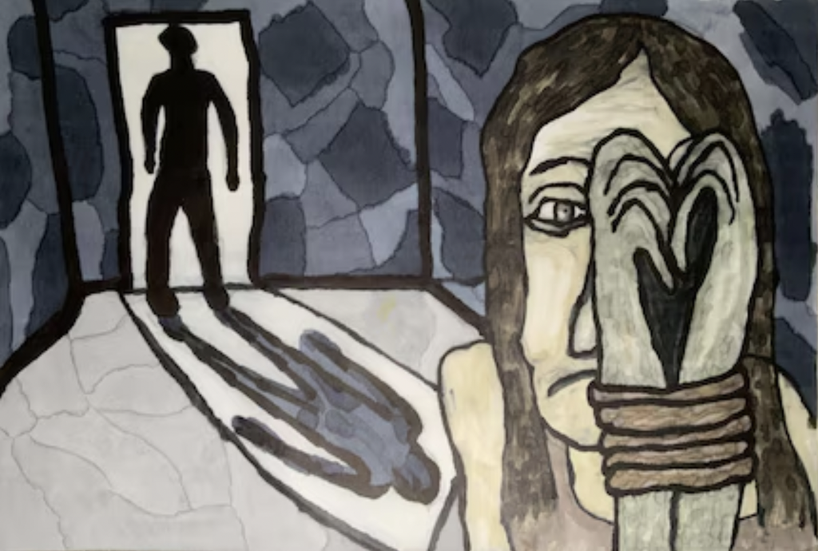

## Future research

The limitations of this study themselves represent significant findings, underscoring the inherent complexity of addressing human trafficking and the challenges in approaching this multifaceted issue. This project calls for future research to address the limitations experienced in this study. This includes:

- **Mitigating the small dataset size issue** by integrating longitudinal (temporal) data and increasing the number of observations through global or regional comparisons
- **Applying neural networks** suitable to time-series data to create more reliable models and also provide insight into trends over time
- Continue researching and finding data on **additional variables** to account for unobserved drivers of human trafficking in order to broaden the current and past research vision
- Perform **Natural Language Processing (NLP)** comparative analysis on the official policies addressing human trafficking in different countries. This would necessitate advanced and sophisticated technology and methods in order to compare policies across languages.

These suggestions provide actionable and realistic pathways for advancing research and developing a more nuanced understanding of human trafficking, contributing to incremental progress toward a safer and more just world.

## Conclusion

This project has provided valuable insights into the complexities of human trafficking and the challenges associated with evaluating government responses through data science. Despite the limitations of a small dataset, limited resources, and the inherent intricacies of human trafficking as an underground crime, the analyses underscored the critical need for more robust and comprehensive frameworks to address these issues. The results emphasize the need for further investigation into the alignment and effectiveness of current evaluation methods, such as the TIP report and the Global Slavery Index, to ensure a more accurate representation of country-level efforts. By addressing the limitations posed in this report and pursuing continued research, future studies can contribute to the development of more nuanced tools for evaluating human trafficking responses, ultimately aiding in the fight against this devastating global issue.

## Acknowledgements

I would like to thank Dr. James Hickman and Dr. Jeff Jacobs of Georgetown University’s Data Science and Analytics program for their unwavering support and valuable insights.